# ADHD management

## Meta-regression: Indirect comparison between combined vs(medication plus psychosocial) and psychosocial

4 psychosocial studies

0 combined studies

Not enough studies to compare psychosocial and combined

### Outcome: cognitive:categorical Intervention: Psychosocial

Outcome name: cognitive Analyzing 0 studies.

No data.

### Outcome: symptom:continuous Intervention: Psychosocial

| ID | measure | mean_ctrl_cont | SD_ctrl_cont | n_ctrl_cont | mean_int_cont | SD_int_cont | n_int_cont | yi | se | study.design |
| --- | --- | --- | --- | --- | --- | --- | --- | --- | --- | --- |
| Champ, 2025{#15151} | ADHDRS-IV-Inv (Attention-Deficit/Hyperactivity Disorder Rating Scale, Investigator-Administered) | 32.440 | 8.580 | 9 | 25.910 | 9.320 | 11 | -0.6949317 | 0.4627023 | RCT |
| Gutman, 2020{#1361} | ASRS (Adult Attention Deficit Hyperactivity Disorder Self-Report Scale) | 65.410 | 5.740 | 12 | 52.090 | 6.470 | 11 | -2.1050296 | 0.5201651 | RCT |
| Kenter, 2023{#2646} | ASRS (Adult ADHD Self-Report Scale) | 48.800 | 9.470 | 53 | 42.600 | 8.050 | 34 | -0.6869483 | 0.2258135 | RCT |
| Solanto, 2010{#1728}; | Conners Observer-IN (Conners Adult ADHD Rating Scales-Observer: Long Version), inattention/memory subscale | 73.190 | 10.330 | 40 | 66.940 | 11.640 | 41 | -0.5621144 | 0.2265848 | RCT |
| Stevenson, 2002{#1753} | ADHD Checklist (DSM-IIIR) | 112.900 | 18.000 | 21 | 72.600 | 27.600 | 19 | -1.7135059 | 0.3700701 | RCT |
| Stevenson, 2003{#9871} | BAARS (Barkley Adult ADHD scale) | 112.900 | 18.000 | 18 | 73.700 | 26.700 | 17 | -1.6917744 | 0.3940384 | RCT |
| Van der Oord, 2020{#1808} | ADHD-RS (ADHD Rating Scale) Inattention | 1.690 | 0.490 | 28 | 1.410 | 0.620 | 30 | -0.4923065 | 0.2667152 | RCT |
| Anastopoulos, 2021{#1080} CBT | CAARS (Conners’ Adult ADHD Rating Scale) | 31.680 | 9.480 | 102 | 28.460 | 9.480 | 95 | -0.3383541 | 0.1435995 | RCT |
| Antshel, 2026{#15276} CBT | ASRS-Inatt. (Adult ADHD Self-Report Scale Inattention) | 27.320 | 3.810 | 78 | 21.770 | 5.270 | 76 | -1.2034816 | 0.1751596 | RCT |
| D’Amelio, 2026{#15404} CBT | ASRS (Adult ADHD Self-Report Scale) | 50.000 | 7.600 | 173 | 44.600 | 8.400 | 164 | -0.6735503 | 0.1120313 | RCT |
| Dittner, 2018{#1261} CBT | CSS (Adult Barkley Current Symptoms Scale) | 29.100 | 7.500 | 19 | 20.800 | 8.800 | 27 | -0.9836881 | 0.3165225 | RCT |
| Moell, 2015{#8589} CBT | ASRS (Adult ADHD Self-Report Scale) Inattention | 27.930 | 3.930 | 27 | 22.920 | 4.340 | 26 | -1.1933815 | 0.2982181 | RCT |
| Nasri, 2023{#2954} CBT | ASRS-v1.1 (Adult ADHD Self-Report Scale version 1.1) | 47.400 | 9.020 | 31 | 40.500 | 10.500 | 36 | -0.6927675 | 0.2522249 | RCT |
| Virta, 2010{#3410} CBT | BADDS (Brown Attention Deficit Disorder Scale – Adult Version) | 70.000 | 14.200 | 10 | 71.500 | 18.600 | 10 | 0.0868120 | 0.4474242 | RCT |
| Virta, 2010{#8307} CBT | BADDS (Brown Attention deficit disorder Scale – adult version) | 70.000 | 14.200 | 7 | 71.900 | 18.400 | 9 | 0.1073573 | 0.5043099 | RCT |
| van Emmerik, 2019{#1813} CBT-ADHD/SUD | ARS (ADHD Rating Scale) | 31.290 | 10.370 | 39 | 28.470 | 8.370 | 39 | -0.2962964 | 0.2276946 | RCT |
| Fleming, 2015{#1314} DBT | BAARS-IV (Barkley Adult ADHD Rating Scale–IV) | 21.060 | 4.120 | 16 | 18.060 | 4.920 | 17 | -0.6431667 | 0.3571990 | RCT |
| Halmoy, 2022{#1366} DBT | ASRS (Adult ADHD Self-Report Scale) | 45.400 | 9.300 | 47 | 38.700 | 9.000 | 49 | -0.7265357 | 0.2107937 | RCT |
| Ulusoy, 2024{#3386} DBT | ASRS (Adult ADHD Self-Report Scale) | 72.060 | 9.220 | 16 | 54.250 | 10.420 | 16 | -1.7645683 | 0.4167152 | RCT |
| Gu, 2018{#1360} MBCT | CAARS-S (Conners’ Adult ADHD Self-Rating Scale) ADHD Index | 72.150 | 8.440 | 26 | 61.500 | 9.810 | 28 | -1.1436887 | 0.2937468 | RCT |
| Hepark, 2019{#1379} MBCT | CAARS (Conners’ Adult ADHD Rating Scale) investigator rated | 28.000 | 7.500 | 48 | 21.500 | 7.700 | 55 | -0.8480474 | 0.2061707 | RCT |
| Janssen, 2019{#1416} MBCT | CAARS-INV (Conners’ Adult ADHD Rating Scale-Investigator) | 29.200 | 6.800 | 55 | 25.400 | 9.500 | 52 | -0.4588133 | 0.1959497 | RCT |
| Schoenberg, 2013{#1696} MBCT | CAARS-SV (Conners’ Adult ADHD Self-rating Scale) | 31.300 | 6.700 | 20 | 23.000 | 8.500 | 24 | -1.0533738 | 0.3229175 | RCT |
| Skliarova, 2025{#11405} Psychoed | ASRS (Adult ADHD Self-Reported Scale, total score) | 47.586 | 10.839 | 17 | 47.673 | 10.685 | 17 | 0.0078926 | 0.3429985 | RCT |

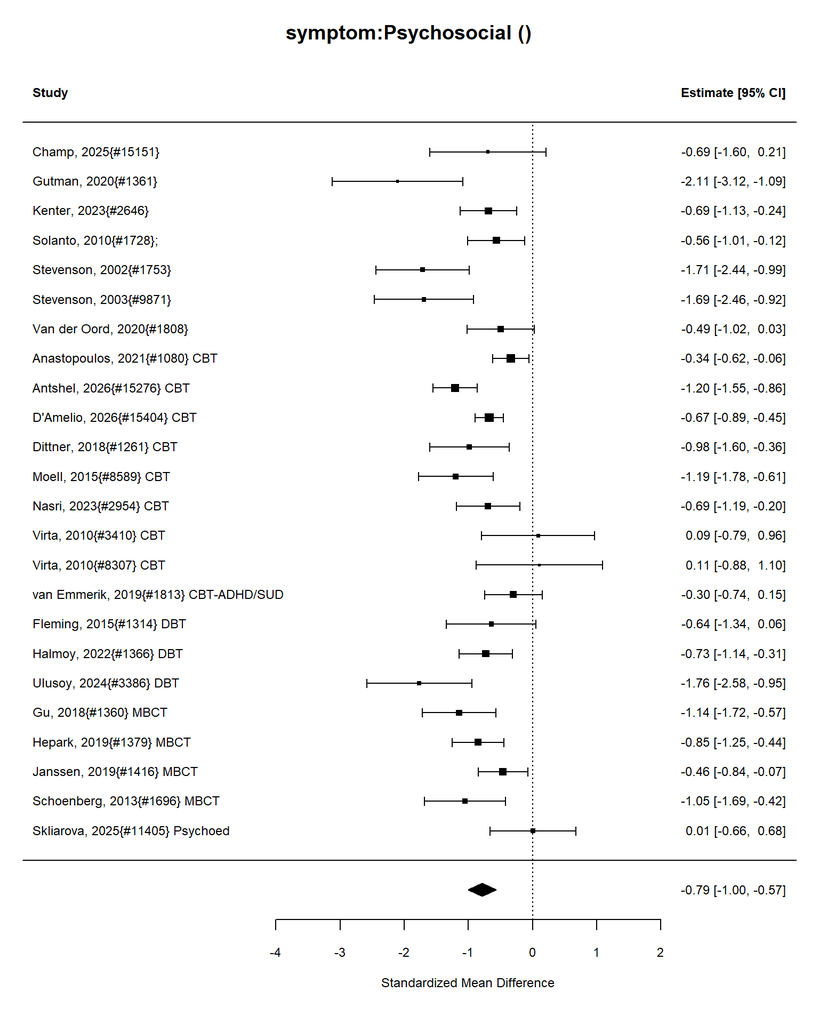

| estimate | conf.low | conf.high |
| --- | --- | --- |
| -0.79 | -1 | -0.57 |

Number of studies = 24

Intervention sample = 903

Control sample = 912

Total sample = 1815.

I-squared = 68 %

Convert Effect Size to Real Units

Estimated effect in original units = -7.01.

##### Publication Bias Tests

###### Begg (non-parametric)

Rank Correlation Test for Funnel Plot Asymmetry Kendall’s tau = -0.1739, p = 0.2466

###### Egger (parametric)

Regression Test for Funnel Plot Asymmetry

Model: mixed-effects meta-regression model Predictor: standard error

Test for Funnel Plot Asymmetry: t = -1.2638, df = 22, p = 0.2195 Limit Estimate (as sei -> 0): b = -0.4448 (CI: -1.0422, 0.1526)

###### Trim and Fill

Estimate and Cis

|  | estimate | ci.lb | ci.ub |
| --- | --- | --- | --- |
| intrcpt | -0.79 | -1 | -0.57 |

### Meta-regression: stimulant vs non-stimulant

0 stimulant studies

0 nonstimulant studies

Not enough studies to compare stimulant and nonstimulant

### Meta-regression: AMPH vs MPH

### AMPH vs MPH meta-regression

0n AMPH studies

0 nMPH studies

Not enough studies to compare AMPH and MPH

## Meta-regression: Indirect comparison between combined vs(medication plus psychosocial) and medication

0 medication studies

0 combined studies

Not enough studies to compare medication and combined

## Meta-regression: Indirect comparison between combined vs(medication plus psychosocial) and psychosocial

24 psychosocial studies

0 combined studies

Not enough studies to compare psychosocial and combined

### Control Types

| control | n |
| --- | --- |
| Attention-matched control | 1 |
| No intervention | 1 |
| Other | 1 |
| TAU | 1 |
| Waitlist | 2 |

| ID | measure | yi | se | study.design |
| --- | --- | --- | --- | --- |
| Kenter, 2023{#2646} | ASRS (Adult ADHD Self-Report Scale), number with positive, reliable change | -1.47 | 0.38 | RCT |
| Anastopoulos, 2021{#1080} CBT | CAARS (Conners’ Adult ADHD Rating Scale), number with reliable improvement | -0.67 | 0.17 | RCT |
| Huang, 2019{#1399} CBT | ADHD-Rating Scale, Number of patients with treatment response | -0.79 | 0.57 | RCT |
| Hirvikoski, 2011{#1391} DBT | ADHD Current Symptom Scale, number with 30% reduction in score | -2.51 | 1.43 | RCT |
| Janssen, 2019{#1416} MBCT | CAARS-INV (Conners’ Adult ADHD Rating Scale–Investigator Rated) scores at post-treatment based on a ≥30% reduction | -0.50 | 0.24 | RCT |
| Virta, 2010{#8307} (C) CBT | BADDS, SCL-16, and Adult ADHD Self-Report Scale, number of improved participants | -0.67 | 0.61 | RCT |

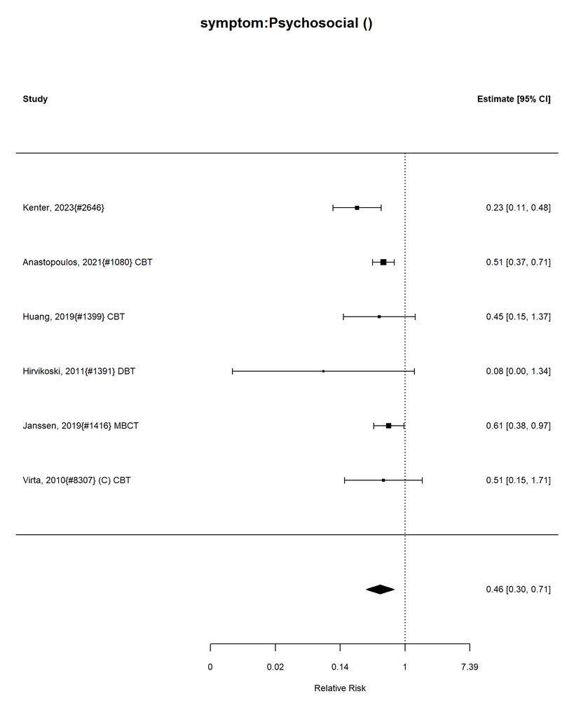

Number of studies = 6  
Intervention sample = 227  
Control sample = 247  
Total sample = 474

### Relative Risk Estimate

|  | estimate | se | tval | df | pval | ci.lb | ci.ub |
| --- | --- | --- | --- | --- | --- | --- | --- |
| intrcpt | 0.4630131 | 1.185305 | 0.0097548 | 148.4132 | 1.01005 | 0.3011942 | 0.7117703 |

I-squared = 24 %

##### Publication Bias Tests

###### Begg (non-parametric)

```
Rank Correlation Test for Funnel Plot Asymmetry

Kendall's tau = -0.3333, p = 0.4694
```

###### Egger (parametric)

```
Regression Test for Funnel Plot Asymmetry

Model:     mixed-effects meta-regression model
Predictor: standard error

Test for Funnel Plot Asymmetry: t = -1.4367, df = 4, p = 0.2242
Limit Estimate (as sei -> 0):   b = -0.4361 (CI: -1.1092, 0.2371)
```

###### Trim and Fill

Estimate and CIs

|  | estimate | ci.lb | ci.ub |
| --- | --- | --- | --- |
| intrcpt | 0.48 | 0.35 | 0.64 |

TrimFill Relative Risk Estimate: 0

###### int_stimulant vs int_nonstimulant meta-regression

### Meta-regression: stimulant vs non-stimulant

0 stimulant studies

0 nonstimulant studies

Not enough studies to compare stimulant and nonstimulant

### Meta-regression: AMPH vs MPH

### AMPH vs MPH meta-regression

0n AMPH studies

0 nMPH studies

Not enough studies to compare AMPH and MPH

## Meta-regression: Indirect comparison between combined vs(medication plus psychosocial) and medication

0 medication studies

0 combined studies

Not enough studies to compare medication and combined

## Meta-regression: Indirect comparison between combined vs(medication plus psychosocial) and psychosocial

6 psychosocial studies

0 combined studies

Not enough studies to compare psychosocial and combined

### Outcome: substance_use:continuous Intervention: Psychosocial

No data #1.

### Outcome: substance_use:categorical Intervention: Psychosocial

Outcome name: substance_use Analyzing 0 studies.

No data.

### Outcome: relationship:continuous Intervention: Psychosocial

| ID | measure | mean_ctrl_cont | SD_ctrl_cont | n_ctrl_cont | mean_int_cont | SD_int_cont | n_int_cont | yi | se | study.design |
| --- | --- | --- | --- | --- | --- | --- | --- | --- | --- | --- |
| Anastopoulos, 2021{#1080} CBT | AIM-A (ADHD Impact Module-Adult ) Relationship scale | 66.83 | 19.92 | 96 | 70.54 | 21.07 | 92 | -0.1803265 | 0.1461941 | RCT |
| Hirvikowski, 2017{#1390} Psychoed | QAFM (Questions about Family Member) Critical Remarks scale | 21.71 | 7.08 | 28 | 22.17 | 8.30 | 41 | 0.0580786 | 0.2452121 | RCT |

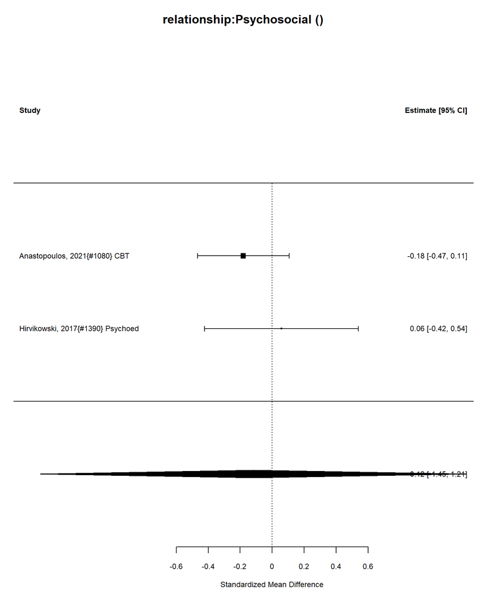

| estimate | conf.low | conf.high |
| --- | --- | --- |
| -0.12 | -1.45 | 1.21 |

Number of studies = 2

Intervention sample = 133

Control sample = 124

Total sample = 257.

I-squared = 0 %

Convert Effect Size to Real Units

Estimated effect in original units = -1.59.

### Outcome: relationship:categorical Intervention: Psychosocial

Outcome name: relationship Analyzing 0 studies.

No data.

### Outcome: BP:continuous Intervention: Psychosocial

No data #1.

### Outcome: BP:categorical Intervention: Psychosocial

Outcome name: BP Analyzing 0 studies.

No data.

### Outcome: sleep_disturbance:continuous Intervention: Psychosocial

| ID | measure | mean_ctrl_cont | SD_ctrl_cont | n_ctrl_cont | mean_int_cont | SD_int_cont | n_int_cont | yi | se | study.design |
| --- | --- | --- | --- | --- | --- | --- | --- | --- | --- | --- |
| Nasri, 2023{#2954} CBT | ISI (Insomnia Severity Index) | 12 | 6.15 | 31 | 10 | 6.56 | 36 | -0.3101356 | 0.2464825 | RCT |

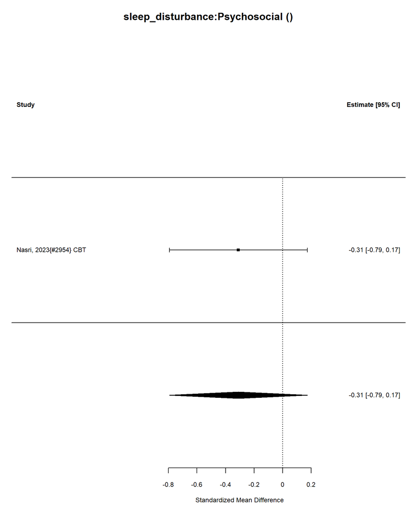

| estimate | conf.low | conf.high |
| --- | --- | --- |
| -0.31 | -0.79 | 0.17 |

Number of studies = 1

Intervention sample = 36

Control sample = 31

Total sample = 67.

I-squared = 0 %

Convert Effect Size to Real Units

Estimated effect in original units = -1.91.

### Outcome: sleep_disturbance:categorical Intervention: Psychosocial

Outcome name: sleep_disturbance Analyzing 0 studies.

No data.

### Outcome: AEs:continuous Intervention: Psychosocial

No data #1.

### Outcome: AEs:categorical Intervention: Psychosocial

Outcome name: AEs Analyzing 3 studies.

Analyzing 3 studies.

### Control Types

| control | n |
| --- | --- |
| Attention-matched control | 1 |
| TAU | 1 |
| Waitlist | 1 |

| ID | measure | yi | se | study.design |
| --- | --- | --- | --- | --- |
| Dittner, 2018{#1261} CBT | Number of participants with adverse events | 0.51 | 0.68 | RCT |
| Hirvikoski, 2011{#1391} DBT | Self-Reported Adverse Events | -0.05 | 0.95 | RCT |
| Hirvikowski, 2017{#1390} Psychoed | Number of participants reporting adverse events | -0.30 | 1.99 | RCT |

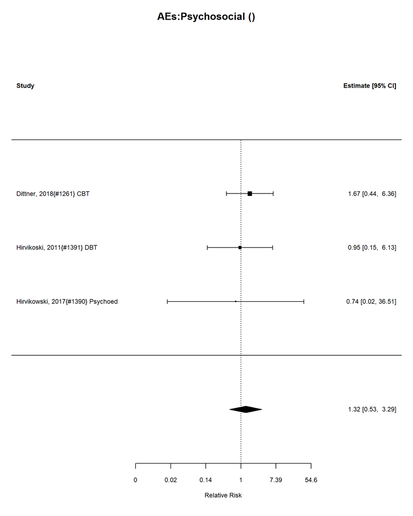

Number of studies = 3  
Intervention sample = 93  
Control sample = 81  
Total sample = 174

### Relative Risk Estimate

|  | estimate | se | tval | df | pval | ci.lb | ci.ub |
| --- | --- | --- | --- | --- | --- | --- | --- |
| intrcpt | 1.32313 | 1.233678 | 3.632787 | 7.389056 | 1.377128 | 0.5272924 | 3.287081 |

I-squared = 0 %

##### Publication Bias Tests

###### Begg (non-parametric)

```
Rank Correlation Test for Funnel Plot Asymmetry

Kendall's tau = -0.3333, p = 1.0000
```

###### Egger (parametric)

```
Regression Test for Funnel Plot Asymmetry

Model:     mixed-effects meta-regression model
Predictor: standard error

Test for Funnel Plot Asymmetry: t = -1.3352, df = 1, p = 0.4092
Limit Estimate (as sei -> 0):   b =  0.8923 (CI: -5.4092, 7.1938)
```

###### Trim and Fill

Estimate and CIs

|  | estimate | ci.lb | ci.ub |
| --- | --- | --- | --- |
| intrcpt | 1.67 | 0.69 | 4.05 |

TrimFill Relative Risk Estimate: 2

###### int_stimulant vs int_nonstimulant meta-regression

### Meta-regression: stimulant vs non-stimulant

0 stimulant studies

0 nonstimulant studies

Not enough studies to compare stimulant and nonstimulant

### Meta-regression: AMPH vs MPH

### AMPH vs MPH meta-regression

0n AMPH studies

0 nMPH studies

Not enough studies to compare AMPH and MPH

## Meta-regression: Indirect comparison between combined vs(medication plus psychosocial) and medication

0 medication studies

0 combined studies

Not enough studies to compare medication and combined

## Meta-regression: Indirect comparison between combined vs(medication plus psychosocial) and psychosocial

3 psychosocial studies

0 combined studies

Not enough studies to compare psychosocial and combined

### Outcome: mortality:continuous Intervention: Psychosocial

No data #1.

### Outcome: mortality:categorical Intervention: Psychosocial

Outcome name: mortality Analyzing 0 studies.

No data.

### Outcome: behavior:continuous Intervention: Psychosocial

| ID | measure | mean_ctrl_cont | SD_ctrl_cont | n_ctrl_cont | mean_int_cont | SD_int_cont | n_int_cont | yi | se | study.design |
| --- | --- | --- | --- | --- | --- | --- | --- | --- | --- | --- |
| Van der Oord, 2020{#1808} | ASR (Adult Self-Report) Aggressive behavior scale | 7.15 | 4.53 | 28 | 5.17 | 4.61 | 30 | 0.4272775 | 0.265747 | RCT |

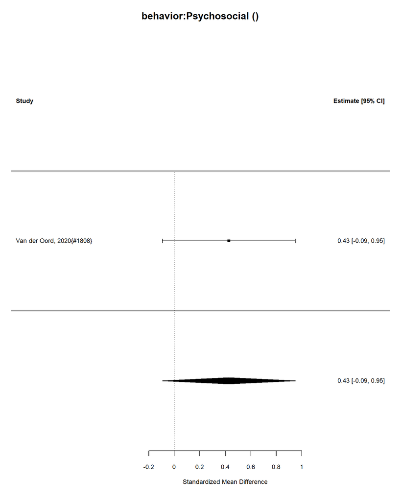

| estimate | conf.low | conf.high |
| --- | --- | --- |
| 0.43 | -0.09 | 0.95 |

Number of studies = 1

Intervention sample = 30

Control sample = 28

Total sample = 58.

I-squared = 0 %

Convert Effect Size to Real Units

Estimated effect in original units = 1.94.

### Outcome: behavior:categorical Intervention: Psychosocial

Outcome name: behavior Analyzing 0 studies.

No data.

### Outcome: appetite:continuous Intervention: Psychosocial

No data #1.

### Outcome: appetite:categorical Intervention: Psychosocial

Outcome name: appetite Analyzing 0 studies.

No data.

### Outcome: mood:continuous Intervention: Psychosocial

No data #1.

### Outcome: mood:categorical Intervention: Psychosocial

Outcome name: mood Analyzing 0 studies.

No data.

# Subintervention Analysis

Perform meta-analyses separately for MPH, AMPH, and NRI’s on ADHD symptoms, cognitive performance, and adverse events (p.28)? Reviewers and readers will absolutely expect and want it.

int_methylphenidate int_amphetamine int_NRI

• Perform meta-analyses separately for MBCT, DBT, and CBT on ADHD symptoms (p.33)? - int_mindfulness - int_DBT - int_CBT_only

Continuous Outcomes: - cognitive symptom AEs Categorical outcomes: - cognitive symptom AEs

```r
#Only doing specific interventions, and only specific outcomes.



sub_interventions <-
  c("longterm",
    "int_stimulant", "int_nonstimulant",
    "int_methylphenidate", "int_amphetamine",
    "int_NRI", "int_alpha_agonist", "int_atomoxetine",
    "int_bupropion",
    "int_mindfulness", "int_DBT_only", "int_CBT_only", "int_MBCT_only"
    )


rm(d_short)

for (current_intervention in sort(unique(sub_interventions))) {

  medication_analysis <- FALSE
  if (current_intervention %in%
      c("int_methylphenidate", "int_amphetamine", "int_NRI",
        "int_stimulant",
        "int_nonstimulant")) {
    medication_analysis <- TRUE
  }

  d_short <- d[d[current_intervention] == current_intervention, ]

  medication_analysis <- FALSE
  if (current_intervention %in%
      c("int_methylphenidate", "int_amphetamine", "int_NRI",
        "int_stimulant",
        "int_nonstimulant")) {
    medication_analysis <- TRUE
  }


  cat(glue::glue("<h2> MPH, AMPH, and NRI's Section:
                 Intervention: {current_intervention}</h2> "))
  for (var_num in 1:length(list_variable_types)) {

    outcome_name <- list_variable_types[[var_num]]["var"]
    outcome_type <- list_variable_types[[var_num]]["type"]

    cat(
      glue::glue("<h2> Intervention: {current_intervention} <br>
                <h3>Outcome: {outcome_name}:{outcome_type}</h3><p>")
    )

    if (outcome_type == "continuous") {
      res <- ContMA(
        data = d_short,
        label = "ID",
        outcome = outcome_name,
        comparator_vs_int = comparator_vs_int
      )
    }
    if (outcome_type == "categorical") {
      res <- CatMA(
        data = d_short,
        label = "ID",
        outcome = outcome_name,
        comparator_vs_int = comparator_vs_int
      )
    }
  }
}
```

## MPH, AMPH, and NRI’s Section: Intervention: int_alpha_agonist

## Intervention: int_alpha_agonist

### Outcome: functional:continuous

No data #1.

## Intervention: int_alpha_agonist

### Outcome: functional:categorical

Analyzing 0 studies.

No data.

## Intervention: int_alpha_agonist

### Outcome: cognitive:continuous

No data #1.

## Intervention: int_alpha_agonist

### Outcome: cognitive:categorical

Analyzing 0 studies.

No data.

## Intervention: int_alpha_agonist

### Outcome: symptom:continuous

No data #1.

## Intervention: int_alpha_agonist

### Outcome: symptom:categorical

Analyzing 0 studies.

No data.

## Intervention: int_alpha_agonist

### Outcome: substance_use:continuous

No data #1.

## Intervention: int_alpha_agonist

### Outcome: substance_use:categorical

Analyzing 0 studies.

No data.

## Intervention: int_alpha_agonist

### Outcome: relationship:continuous

No data #1.

## Intervention: int_alpha_agonist

### Outcome: relationship:categorical

Analyzing 0 studies.

No data.

## Intervention: int_alpha_agonist

### Outcome: BP:continuous

No data #1.

## Intervention: int_alpha_agonist

### Outcome: BP:categorical

Analyzing 0 studies.

No data.

## Intervention: int_alpha_agonist

### Outcome: sleep_disturbance:continuous

No data #1.

## Intervention: int_alpha_agonist

### Outcome: sleep_disturbance:categorical

Analyzing 0 studies.

No data.

## Intervention: int_alpha_agonist

### Outcome: AEs:continuous

No data #1.

## Intervention: int_alpha_agonist

### Outcome: AEs:categorical

Analyzing 0 studies.

No data.

## Intervention: int_alpha_agonist

### Outcome: mortality:continuous

No data #1.

## Intervention: int_alpha_agonist

### Outcome: mortality:categorical

Analyzing 0 studies.

No data.

## Intervention: int_alpha_agonist

### Outcome: behavior:continuous

No data #1.

## Intervention: int_alpha_agonist

### Outcome: behavior:categorical

Analyzing 0 studies.

No data.

## Intervention: int_alpha_agonist

### Outcome: appetite:continuous

No data #1.

## Intervention: int_alpha_agonist

### Outcome: appetite:categorical

Analyzing 0 studies.

No data.

## Intervention: int_alpha_agonist

### Outcome: mood:continuous

No data #1.

## Intervention: int_alpha_agonist

### Outcome: mood:categorical

Analyzing 0 studies.

No data.

## MPH, AMPH, and NRI’s Section: Intervention: int_amphetamine

## Intervention: int_amphetamine

### Outcome: functional:continuous

| ID | measure | mean_ctrl_cont | SD_ctrl_cont | n_ctrl_cont | mean_int_cont | SD_int_cont | n_int_cont | yi | se | study.design |
| --- | --- | --- | --- | --- | --- | --- | --- | --- | --- | --- |
| Dupaul, 2012{#1272} S-AMPH-LDX | BRIEF-A (Behavior Rating Inventory of Executive Function–Adult) General Executive Composite | 59.59 | 11.091 | 22 | 51.55 | 11.835 | 22 | -0.6884123 | 0.3103135 | RCT |

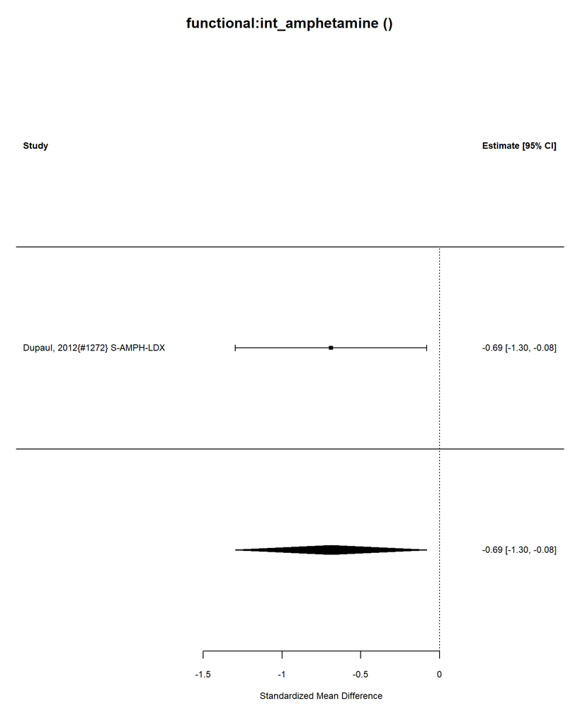

| estimate | conf.low | conf.high |
| --- | --- | --- |
| -0.69 | -1.3 | -0.08 |

Number of studies = 1

Intervention sample = 22

Control sample = 22

Total sample = 44.

I-squared = 0 %

Convert Effect Size to Real Units

Estimated effect in original units = -7.64.

## Intervention: int_amphetamine

### Outcome: functional:categorical

Analyzing 0 studies.

No data.

## Intervention: int_amphetamine

### Outcome: cognitive:continuous

| ID | measure | mean_ctrl_cont | SD_ctrl_cont | n_ctrl_cont | mean_int_cont | SD_int_cont | n_int_cont | yi | se | study.design |
| --- | --- | --- | --- | --- | --- | --- | --- | --- | --- | --- |
| Taylor, 2000{#1778} S-AMPH-D-IR | COWAT (Controlled Oral Word Association Test) | 75.40 | 25.000 | 21 | 86.50 | 10.600 | 21 | 0.5671747 | 0.3147502 | RCT |
| Dupaul, 2012{#1272} S-AMPH-LDX | CPT-II (Conners’ Continuous Performance Test) Hit Reaction Time–Standard Error | 54.03 | 11.634 | 21 | 46.54 | 9.726 | 21 | 0.6853359 | 0.3175367 | RCT |

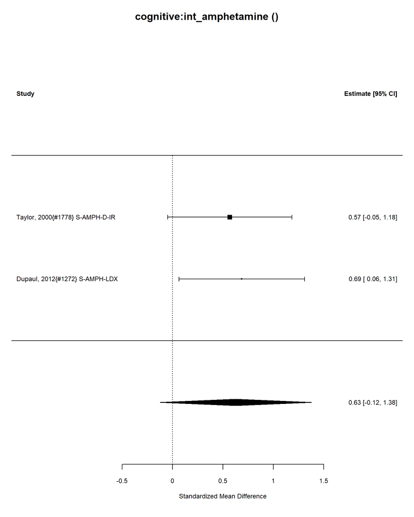

| estimate | conf.low | conf.high |
| --- | --- | --- |
| 0.63 | -0.12 | 1.38 |

Number of studies = 2

Intervention sample = 42

Control sample = 42

Total sample = 84.

I-squared = 0 %

Convert Effect Size to Real Units

Estimated effect in original units = 11.46.

## Intervention: int_amphetamine

### Outcome: cognitive:categorical

Analyzing 0 studies.

No data.

## Intervention: int_amphetamine

### Outcome: symptom:continuous

| ID | measure | mean_ctrl_cont | SD_ctrl_cont | n_ctrl_cont | mean_int_cont | SD_int_cont | n_int_cont | yi | se | study.design |
| --- | --- | --- | --- | --- | --- | --- | --- | --- | --- | --- |
| Taylor, 2000{#1778} S-AMPH-D-IR | DSM-IV ADHD Behavior Checklist for Adults | 28.80 | 10.000 | 21 | 20.00 | 11.30 | 21 | -0.8091786 | 0.3209875 | RCT |
| Dupaul, 2012{#1272} S-AMPH-LDX | CAARS (Conners’ Adult ADHD Rating Scales) ADHD Index | 50.59 | 10.975 | 22 | 45.36 | 10.79 | 22 | -0.4719291 | 0.3056795 | RCT |

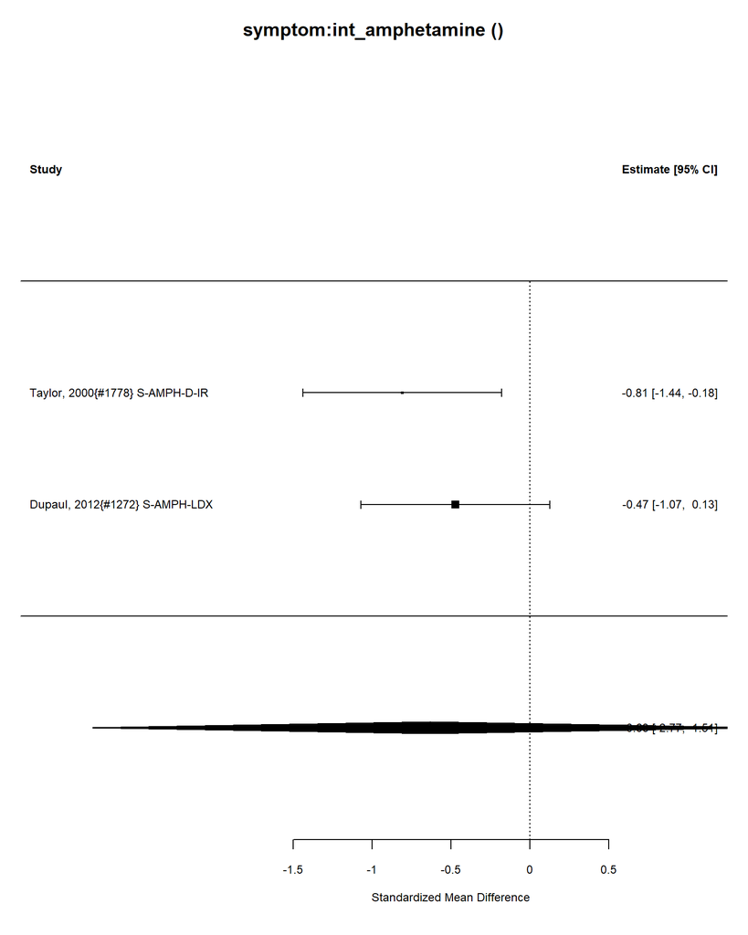

| estimate | conf.low | conf.high |
| --- | --- | --- |
| -0.63 | -2.77 | 1.51 |

Number of studies = 2

Intervention sample = 43

Control sample = 43

Total sample = 86.

I-squared = 0 %

Convert Effect Size to Real Units

Estimated effect in original units = -6.63.

## Intervention: int_amphetamine

### Outcome: symptom:categorical

Analyzing 1 studies.

Analyzing 1 studies.

### Control Types

| control | n |
| --- | --- |
| Placebo | 1 |

| ID | measure | yi | se | study.design |
| --- | --- | --- | --- | --- |
| Levin, 2024{#2765} S-AMPH-MAS-ER | AISRS, participants with at least 30% reduction | -0.15 | 0.21 | RCT |

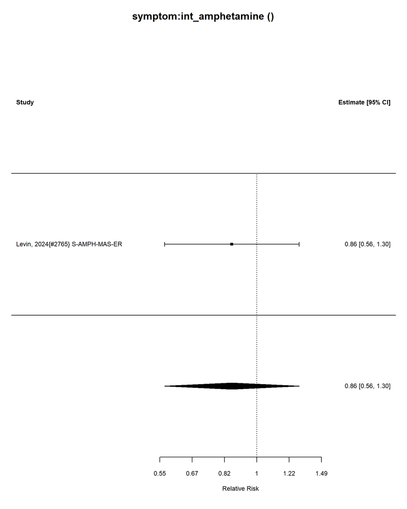

Number of studies = 1  
Intervention sample = 12  
Control sample = 14  
Total sample = 26

### Relative Risk Estimate

|  | estimate | se | zval | pval | ci.lb | ci.ub |
| --- | --- | --- | --- | --- | --- | --- |
| intrcpt | 0.860708 | 1.233678 | 0.4867523 | 1.599994 | 0.5655254 | 1.29693 |

I-squared = 0 %

## Intervention: int_amphetamine

### Outcome: substance_use:continuous

| ID | measure | mean_ctrl_cont | SD_ctrl_cont | n_ctrl_cont | mean_int_cont | SD_int_cont | n_int_cont | yi | se | study.design |
| --- | --- | --- | --- | --- | --- | --- | --- | --- | --- | --- |
| Dupaul, 2012{#1272} S-AMPH-LDX | Substance use frequency - total | 24.64 | 2.498 | 21 | 23.73 | 2.434 | 21 | 0.3620182 | 0.3111243 | RCT |

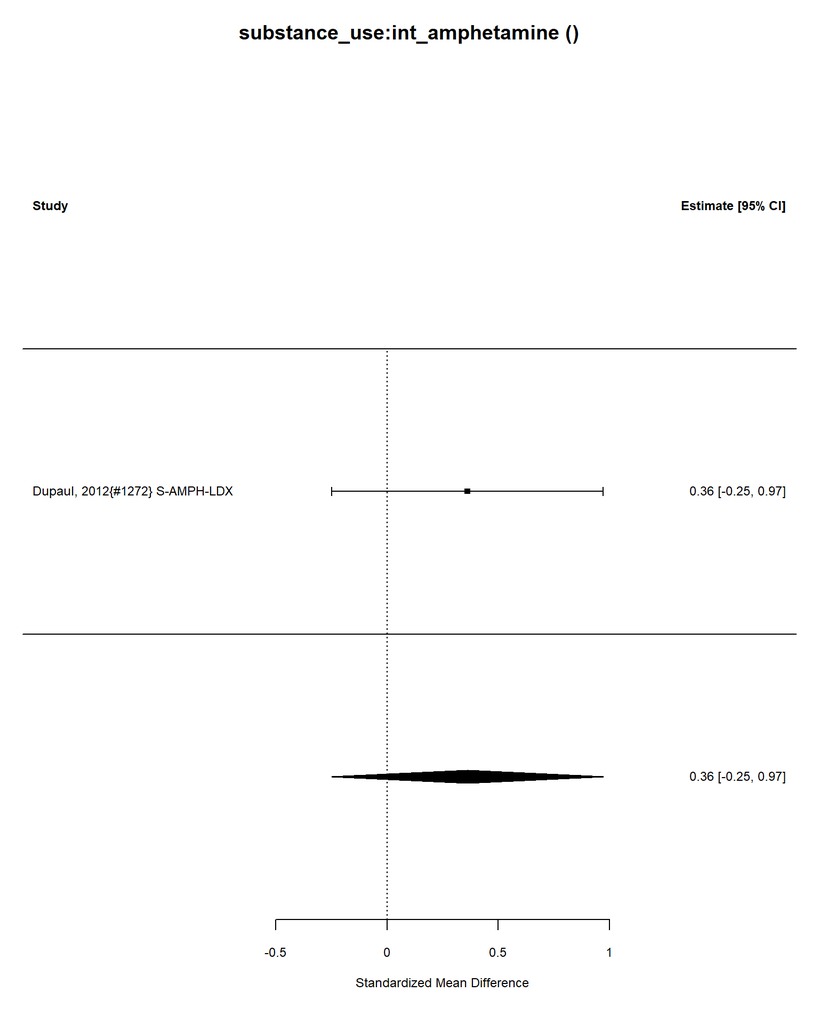

| estimate | conf.low | conf.high |
| --- | --- | --- |
| 0.36 | -0.25 | 0.97 |

Number of studies = 1

Intervention sample = 21

Control sample = 21

Total sample = 42.

I-squared = 0 %

Convert Effect Size to Real Units

Estimated effect in original units = 0.9.

## Intervention: int_amphetamine

### Outcome: substance_use:categorical

Analyzing 2 studies.

Analyzing 2 studies.

### Control Types

| control | n |
| --- | --- |
| Placebo | 2 |

| ID | measure | yi | se | study.design |
| --- | --- | --- | --- | --- |
| Kollins, 2014{#1453} S-AMPH-LDX-ER | Number with 4-week abstinence from smoking, CO levels of 4 ppm or below | -0.39 | 0.64 | RCT |
| Levin, 2024{#2765} S-AMPH-MAS-ER | Number with cannabis abstinence of 2 weeks | -1.74 | 1.51 | RCT |

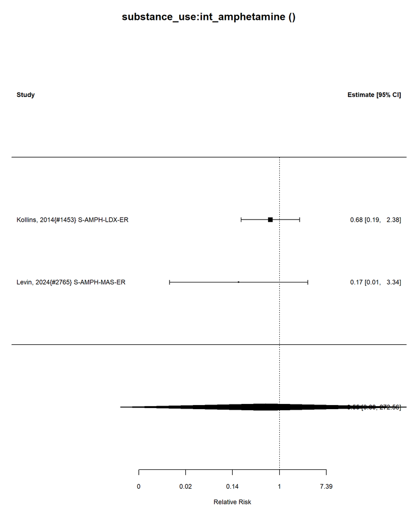

Number of studies = 2  
Intervention sample = 30  
Control sample = 30  
Total sample = 60

### Relative Risk Estimate

|  | estimate | se | tval | df | pval | ci.lb | ci.ub |
| --- | --- | --- | --- | --- | --- | --- | --- |
| intrcpt | 0.5543273 | 1.632316 | 0.2981973 | 2.718282 | 1.552707 | 0.001125 | 273.1442 |

I-squared = 0 %

## Intervention: int_amphetamine

### Outcome: relationship:continuous

No data #1.

## Intervention: int_amphetamine

### Outcome: relationship:categorical

Analyzing 0 studies.

No data.

## Intervention: int_amphetamine

### Outcome: BP:continuous

| ID | measure | mean_ctrl_cont | SD_ctrl_cont | n_ctrl_cont | mean_int_cont | SD_int_cont | n_int_cont | yi | se | study.design |
| --- | --- | --- | --- | --- | --- | --- | --- | --- | --- | --- |
| Dupaul, 2012{#1272} S-AMPH-LDX | Systolic blood pressure mmHg | 122.23 | 18.176 | 21 | 125.41 | 15.795 | 21 | 0.1832328 | 0.3092536 | RCT |

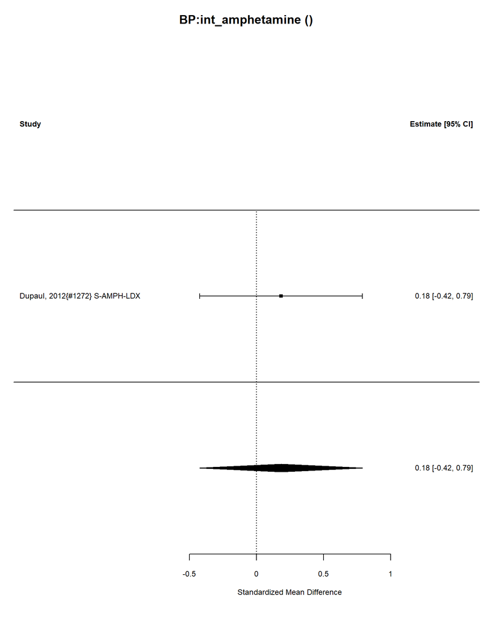

| estimate | conf.low | conf.high |
| --- | --- | --- |
| 0.18 | -0.42 | 0.79 |

Number of studies = 1

Intervention sample = 21

Control sample = 21

Total sample = 42.

I-squared = 0 %

Convert Effect Size to Real Units

Estimated effect in original units = 3.33.

## Intervention: int_amphetamine

### Outcome: BP:categorical

Analyzing 0 studies.

No data.

## Intervention: int_amphetamine

### Outcome: sleep_disturbance:continuous

No data #1.

## Intervention: int_amphetamine

### Outcome: sleep_disturbance:categorical

Analyzing 2 studies.

Analyzing 2 studies.

### Control Types

| control | n |
| --- | --- |
| Placebo | 2 |

| ID | measure | yi | se | study.design |
| --- | --- | --- | --- | --- |
| Kollins, 2014{#1453} S-AMPH-LDX-ER | Insomnia | -1.22 | 1.10 | RCT |
| Cutler, 2022{#1248} S-AMPH-MAS-ER | Number with insomnia | -0.56 | 0.41 | RCT |

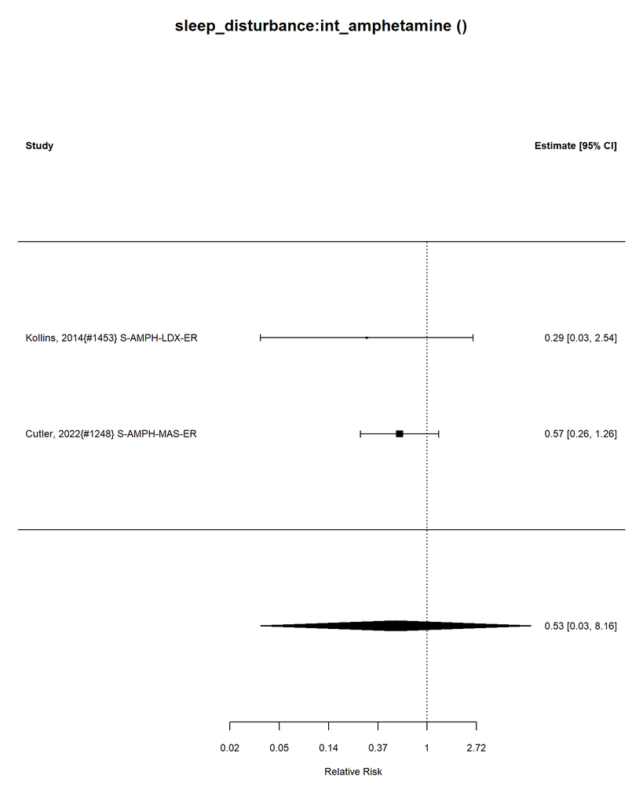

Number of studies = 2  
Intervention sample = 79  
Control sample = 77  
Total sample = 156

### Relative Risk Estimate

|  | estimate | se | tval | df | pval | ci.lb | ci.ub |
| --- | --- | --- | --- | --- | --- | --- | --- |
| intrcpt | 0.5272924 | 1.246077 | 0.0518189 | 2.718282 | 1.233678 | 0.0340475 | 8.16617 |

I-squared = 0 %

## Intervention: int_amphetamine

### Outcome: AEs:continuous

No data #1.

## Intervention: int_amphetamine

### Outcome: AEs:categorical

Analyzing 9 studies.

Analyzing 9 studies.

### Control Types

| control | n |
| --- | --- |
| Placebo | 9 |

| ID | measure | yi | se | study.design |
| --- | --- | --- | --- | --- |
| Paterson, 1999{#1619} S-AMPH-D-IR | Participants with side effects | 1.01 | 0.46 | RCT |
| Adler, 2013{#1050} S-AMPH-LDX-ER | Number of patients experiencing any adverse event | 0.23 | 0.11 | RCT |
| Biederman, 2012{#1115} S-AMPH-LDX-ER | Number of participants with at least 1 adverse event | 0.38 | 0.16 | RCT |
| Brams, 2012{#1150} S-AMPH-LDX-ER | Any treatment emergent adverse event | 0.47 | 0.24 | RCT |
| Kollins, 2014{#1453} S-AMPH-LDX-ER | Number of participants with adverse events | 0.10 | 0.16 | RCT |
| Martin, 2014{#583} S-AMPH-LDX-ER | Number of participants with adverse events | 0.35 | 0.31 | RCT |
| Wigal, 2010{#1865} S-AMPH-LDX-ER | Number of participants with AN adverse event | -0.25 | 0.19 | RCT |
| Cutler, 2022{#1248} S-AMPH-MAS-ER | Number of patients with adverse events | 0.41 | 0.11 | RCT |
| Spencer, 2008{#1743} S-AMPH-MAS-ER | At least 1 treament emerget adverse event | 0.33 | 0.07 | RCT |

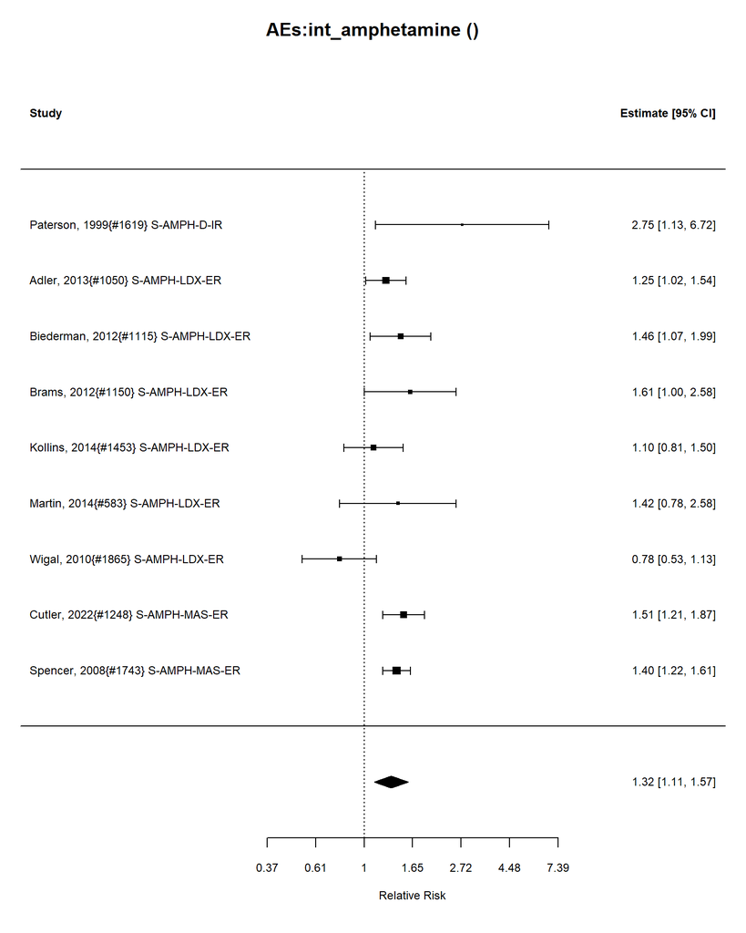

Number of studies = 9  
Intervention sample = 534  
Control sample = 533  
Total sample = 1067

### Relative Risk Estimate

|  | estimate | se | tval | df | pval | ci.lb | ci.ub |
| --- | --- | --- | --- | --- | --- | --- | --- |
| intrcpt | 1.32313 | 1.083287 | 40.85381 | 2980.958 | 1.01005 | 1.116278 | 1.568312 |

I-squared = 39 %

##### Publication Bias Tests

###### Begg (non-parametric)

```
Rank Correlation Test for Funnel Plot Asymmetry

Kendall's tau = 0.1111, p = 0.7614
```

###### Egger (parametric)

```
Regression Test for Funnel Plot Asymmetry

Model:     mixed-effects meta-regression model
Predictor: standard error

Test for Funnel Plot Asymmetry: t = 0.6270, df = 7, p = 0.5506
Limit Estimate (as sei -> 0):   b = 0.1765 (CI: -0.2553, 0.6082)
```

###### Trim and Fill

Estimate and CIs

|  | estimate | ci.lb | ci.ub |
| --- | --- | --- | --- |
| intrcpt | 1.28 | 1.13 | 1.46 |

TrimFill Relative Risk Estimate: 1

###### int_stimulant vs int_nonstimulant meta-regression

### Meta-regression: stimulant vs non-stimulant

9 stimulant studies

0 nonstimulant studies

Not enough studies to compare stimulant and nonstimulant

### Meta-regression: AMPH vs MPH

### AMPH vs MPH meta-regression

9n AMPH studies

0 nMPH studies

Not enough studies to compare AMPH and MPH

## Meta-regression: Indirect comparison between combined vs(medication plus psychosocial) and medication

9 medication studies

0 combined studies

Not enough studies to compare medication and combined

## Meta-regression: Indirect comparison between combined vs(medication plus psychosocial) and psychosocial

0 psychosocial studies

0 combined studies

Not enough studies to compare psychosocial and combined

## Intervention: int_amphetamine

### Outcome: mortality:continuous

No data #1.

## Intervention: int_amphetamine

### Outcome: mortality:categorical

Analyzing 6 studies.

Analyzing 6 studies.

### Control Types

| control | n |
| --- | --- |
| Placebo | 6 |

| ID | measure | yi | se | study.design |
| --- | --- | --- | --- | --- |
| Adler, 2013{#1050} S-AMPH-LDX-ER | Number of deaths | 0.05 | 1.99 | RCT |
| Brams, 2012{#1150} S-AMPH-LDX-ER | Number of deaths | -0.18 | 1.99 | RCT |
| Wigal, 2010{#1865} S-AMPH-LDX-ER | Number of deaths | -0.02 | 2.00 | RCT |
| Cutler, 2022{#1248} S-AMPH-MAS-ER | All-cause mortality | -0.05 | 1.99 | RCT |
| Levin, 2024{#2765} S-AMPH-MAS-ER | All-cause mortality | -0.13 | 1.97 | RCT |
| Spencer, 2008{#1743} S-AMPH-MAS-ER | Number of deaths | 0.01 | 2.00 | RCT |

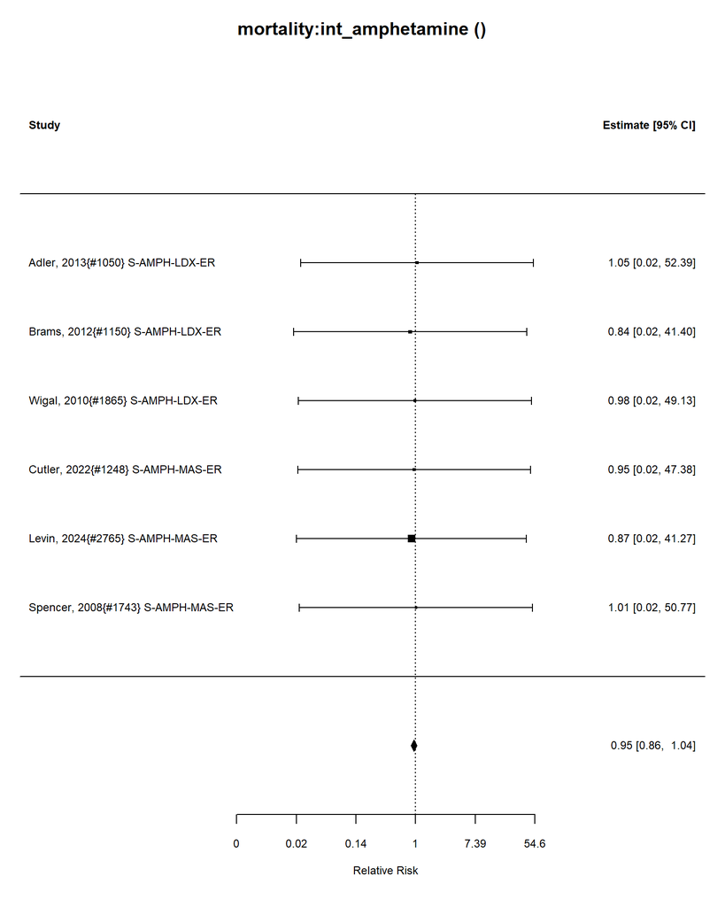

Number of studies = 6  
Intervention sample = 456  
Control sample = 467  
Total sample = 923

### Relative Risk Estimate

|  | estimate | se | tval | df | pval | ci.lb | ci.ub |
| --- | --- | --- | --- | --- | --- | --- | --- |
| intrcpt | 0.9512294 | 1.040811 | 0.2369278 | 148.4132 | 1.233678 | 0.860708 | 1.040811 |

I-squared = 0 %

##### Publication Bias Tests

###### Begg (non-parametric)

```
Rank Correlation Test for Funnel Plot Asymmetry

Kendall's tau = 0.6000, p = 0.1361
```

###### Egger (parametric)

```
Regression Test for Funnel Plot Asymmetry

Model:     mixed-effects meta-regression model
Predictor: standard error

Test for Funnel Plot Asymmetry: t =  1.3514, df = 4, p = 0.2479
Limit Estimate (as sei -> 0):   b = -8.6060 (CI: -26.1802, 8.9682)
```

###### Trim and Fill

Estimate and CIs

|  | estimate | ci.lb | ci.ub |
| --- | --- | --- | --- |
| intrcpt | 0.95 | 0.86 | 1.04 |

TrimFill Relative Risk Estimate: 1

###### int_stimulant vs int_nonstimulant meta-regression

### Meta-regression: stimulant vs non-stimulant

6 stimulant studies

0 nonstimulant studies

Not enough studies to compare stimulant and nonstimulant

### Meta-regression: AMPH vs MPH

### AMPH vs MPH meta-regression

6n AMPH studies

0 nMPH studies

Not enough studies to compare AMPH and MPH

## Meta-regression: Indirect comparison between combined vs(medication plus psychosocial) and medication

6 medication studies

0 combined studies

Not enough studies to compare medication and combined

## Meta-regression: Indirect comparison between combined vs(medication plus psychosocial) and psychosocial

0 psychosocial studies

0 combined studies

Not enough studies to compare psychosocial and combined

## Intervention: int_amphetamine

### Outcome: behavior:continuous

No data #1.

## Intervention: int_amphetamine

### Outcome: behavior:categorical

Analyzing 0 studies.

No data.

## Intervention: int_amphetamine

### Outcome: appetite:continuous

No data #1.

## Intervention: int_amphetamine

### Outcome: appetite:categorical

Analyzing 8 studies.

Analyzing 8 studies.

### Control Types

| control | n |
| --- | --- |
| Placebo | 8 |

| ID | measure | yi | se | study.design |
| --- | --- | --- | --- | --- |
| Taylor, 2000{#1778} S-AMPH-D-IR | Appetite suppression | -2.20 | 1.46 | RCT |
| Adler, 2013{#1050} S-AMPH-LDX-ER | Participants who experineced appetite supression | -1.66 | 0.46 | RCT |
| Biederman, 2012{#1115} S-AMPH-LDX-ER | Decreased appetite | -2.22 | 0.70 | RCT |
| Kollins, 2014{#1453} S-AMPH-LDX-ER | Decreased appetite | -2.45 | 1.43 | RCT |
| Martin, 2014{#583} S-AMPH-LDX-ER | Decreased appetite | -1.04 | 1.10 | RCT |
| Wigal, 2010{#1865} S-AMPH-LDX-ER | Decreased appetite | -0.71 | 0.86 | RCT |
| Cutler, 2022{#1248} S-AMPH-MAS-ER | Decreased appetite | -0.81 | 0.27 | RCT |
| Spencer, 2008{#1743} S-AMPH-MAS-ER | Decreased appetite | -2.59 | 0.72 | RCT |

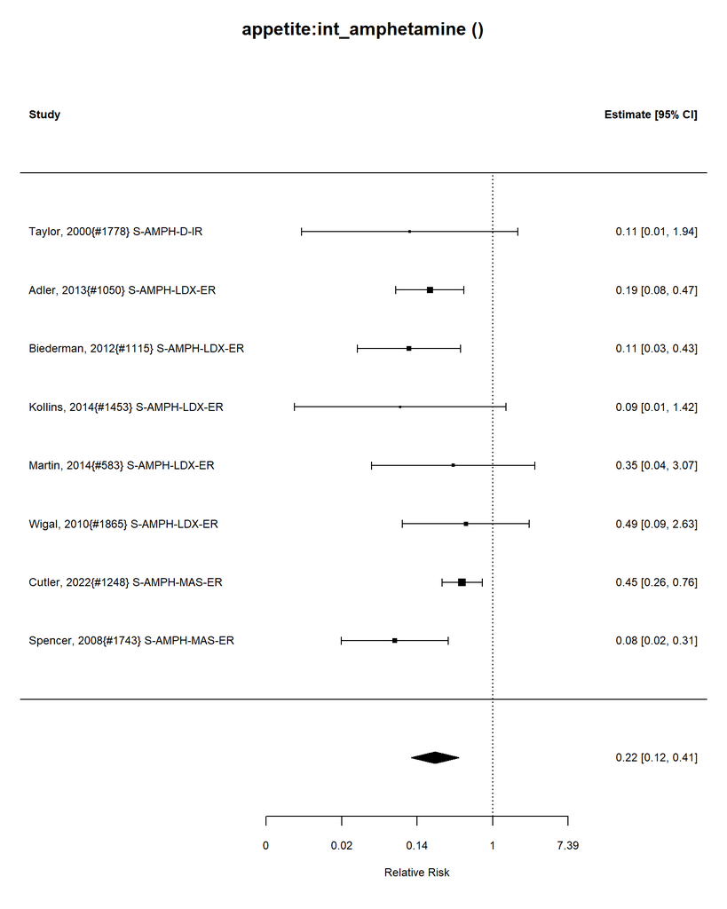

Number of studies = 8  
Intervention sample = 480  
Control sample = 480  
Total sample = 960

### Relative Risk Estimate

|  | estimate | se | tval | df | pval | ci.lb | ci.ub |
| --- | --- | --- | --- | --- | --- | --- | --- |
| intrcpt | 0.2187119 | 1.309964 | 0.0032148 | 1096.633 | 1 | 0.1164842 | 0.4106558 |

I-squared = 38 %

##### Publication Bias Tests

###### Begg (non-parametric)

```
Rank Correlation Test for Funnel Plot Asymmetry

Kendall's tau = -0.0714, p = 0.9049
```

###### Egger (parametric)

```
Regression Test for Funnel Plot Asymmetry

Model:     mixed-effects meta-regression model
Predictor: standard error

Test for Funnel Plot Asymmetry: t = -1.4221, df = 6, p = 0.2048
Limit Estimate (as sei -> 0):   b = -0.8495 (CI: -2.0461, 0.3471)
```

###### Trim and Fill

Estimate and CIs

|  | estimate | ci.lb | ci.ub |
| --- | --- | --- | --- |
| intrcpt | 0.32 | 0.17 | 0.6 |

TrimFill Relative Risk Estimate: 0

###### int_stimulant vs int_nonstimulant meta-regression

### Meta-regression: stimulant vs non-stimulant

8 stimulant studies

0 nonstimulant studies

Not enough studies to compare stimulant and nonstimulant

### Meta-regression: AMPH vs MPH

### AMPH vs MPH meta-regression

8n AMPH studies

0 nMPH studies

Not enough studies to compare AMPH and MPH

## Meta-regression: Indirect comparison between combined vs(medication plus psychosocial) and medication

8 medication studies

0 combined studies

Not enough studies to compare medication and combined

## Meta-regression: Indirect comparison between combined vs(medication plus psychosocial) and psychosocial

0 psychosocial studies

0 combined studies

Not enough studies to compare psychosocial and combined

## Intervention: int_amphetamine

### Outcome: mood:continuous

No data #1.

## Intervention: int_amphetamine

### Outcome: mood:categorical

Analyzing 6 studies.

Analyzing 6 studies.

### Control Types

| control | n |
| --- | --- |
| Placebo | 6 |

| ID | measure | yi | se | study.design |
| --- | --- | --- | --- | --- |
| Taylor, 2000{#1778} S-AMPH-D-IR | Irritability | -0.41 | 0.86 | RCT |
| Adler, 2013{#1050} S-AMPH-LDX-ER | Irritability | -0.99 | 0.66 | RCT |
| Biederman, 2012{#1115} S-AMPH-LDX-ER | Agitated/irritable | -1.58 | 1.53 | RCT |
| Kollins, 2014{#1453} S-AMPH-LDX-ER | Irritability | -0.97 | 1.10 | RCT |
| Cutler, 2022{#1248} S-AMPH-MAS-ER | Irritability | -0.84 | 0.51 | RCT |
| Levin, 2024{#2765} S-AMPH-MAS-ER | Irritable | -1.23 | 1.59 | RCT |

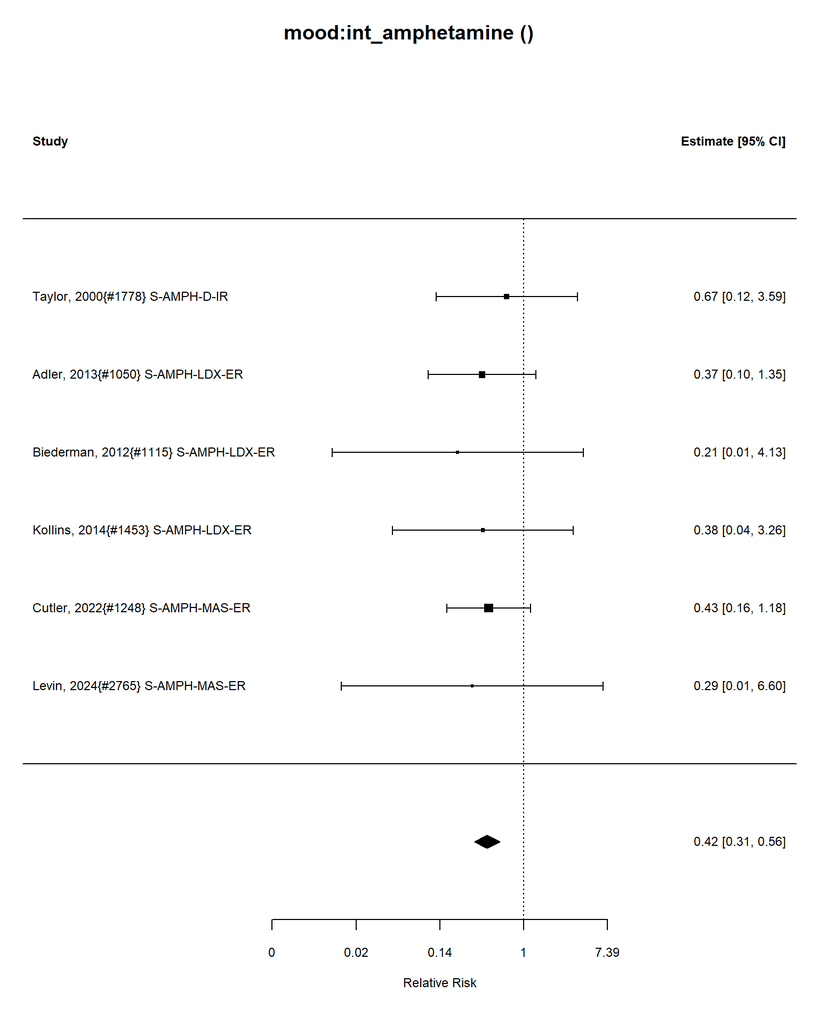

Number of studies = 6  
Intervention sample = 223  
Control sample = 226  
Total sample = 449

### Relative Risk Estimate

|  | estimate | se | tval | df | pval | ci.lb | ci.ub |
| --- | --- | --- | --- | --- | --- | --- | --- |
| intrcpt | 0.4147829 | 1.127497 | 0.0004955 | 148.4132 | 1 | 0.3103669 | 0.5598984 |

I-squared = 0 %

##### Publication Bias Tests

###### Begg (non-parametric)

```
Rank Correlation Test for Funnel Plot Asymmetry

Kendall's tau = -0.4667, p = 0.2722
```

###### Egger (parametric)

```
Regression Test for Funnel Plot Asymmetry

Model:     mixed-effects meta-regression model
Predictor: standard error

Test for Funnel Plot Asymmetry: t = -0.9737, df = 4, p = 0.3853
Limit Estimate (as sei -> 0):   b = -0.6077 (CI: -1.4373, 0.2219)
```

###### Trim and Fill

Estimate and CIs

|  | estimate | ci.lb | ci.ub |
| --- | --- | --- | --- |
| intrcpt | 0.44 | 0.24 | 0.82 |

TrimFill Relative Risk Estimate: 0

###### int_stimulant vs int_nonstimulant meta-regression

### Meta-regression: stimulant vs non-stimulant

6 stimulant studies

0 nonstimulant studies

Not enough studies to compare stimulant and nonstimulant

### Meta-regression: AMPH vs MPH

### AMPH vs MPH meta-regression

6n AMPH studies

0 nMPH studies

Not enough studies to compare AMPH and MPH